# Illustrative case study 2

Thomas Debray

This report was generated on 11 oktober, 2022

# Data source

The International Stroke Trial (IST) was a large, multi-center, randomized, placebo-controlled trial including 19435 stroke patients. Individual participant data are available from [Edinburgh DataShare](https://datashare.ed.ac.uk/handle/10283/124). The IST evaluated the effect of Aspirin on a primary composite outcome of death or dependency (i.e. absence of autonomy) at 6 months (binary outcome). In this illustrative case study, we focus on 9148 patients from IST database version 2 that were randomized to receive Aspirin.

We excluded patients with

- Missing data for the primary outcome (N = 150)
- No information on whether Aspirin was administered within 3 days prior to randomisation (N = 984)
- No information on whether Heparin was administered within 24 hours prior to randomisation (N = 344)
- No information on the presence of atrial fibrillation (N = 984)

Amongst patients enrolled in the Aspirin arm of the International Stroke Trial, less than a quarter received the treatment between 0 and 8 hours following the onset of symptoms (23.6%, N = 2161). In this group, 1443 (66.8%) patients were recorded with death or dependency at 6 months versus 4248 (60.8%) in the group of patients who received Aspirin later (after 8 hours).

We here consider the following baseline covariates (some of which were imputed):

Baseline characteristics of the patients that were administered Aspirin in the IST.

|  | Early Aspirin administration (N=2161) | Late Aspirin administration (N=6987) | Overall (N=9148) |
| --- | --- | --- | --- |
| Age (years) |  |  |  |
| Mean (SD) | 72.6 (11.5) | 71.6 (11.7) | 71.9 (11.6) |
| Median [Min, Max] | 74.0 [25.0, 98.0] | 73.0 [20.0, 98.0] | 73.0 [20.0, 98.0] |
| Systolic blood pressure at randomisation (mmHg) |  |  |  |
| Mean (SD) | 161 (28.3) | 160 (27.7) | 160 (27.8) |
| Median [Min, Max] | 160 [80.0, 260] | 160 [70.0, 284] | 160 [70.0, 284] |
| Gender |  |  |  |
| Female | 1015 (47.0%) | 3296 (47.2%) | 4311 (47.1%) |
| Male | 1146 (53.0%) | 3691 (52.8%) | 4837 (52.9%) |
| Conscious state at randomisation |  |  |  |
| Fully alert | 1507 (69.7%) | 5513 (78.9%) | 7020 (76.7%) |
| Drowsy | 624 (28.9%) | 1380 (19.8%) | 2004 (21.9%) |
| Unconscious | 30 (1.4%) | 94 (1.3%) | 124 (1.4%) |
| CT before randomisation |  |  |  |
| No | 970 (44.9%) | 2068 (29.6%) | 3038 (33.2%) |
| Yes | 1191 (55.1%) | 4919 (70.4%) | 6110 (66.8%) |
| Infarct visible on CT |  |  |  |
| No | 1788 (82.7%) | 4404 (63.0%) | 6192 (67.7%) |
| Yes | 373 (17.3%) | 2583 (37.0%) | 2956 (32.3%) |
| Stroke subtype |  |  |  |
| PACS | 860 (39.8%) | 2830 (40.5%) | 3690 (40.3%) |
| TACS | 692 (32.0%) | 1494 (21.4%) | 2186 (23.9%) |
| POCS | 205 (9.5%) | 850 (12.2%) | 1055 (11.5%) |
| LACS | 400 (18.5%) | 1796 (25.7%) | 2196 (24.0%) |
| Other | 4 (0.2%) | 17 (0.2%) | 21 (0.2%) |
| Face deficit |  |  |  |
| No | 458 (21.2%) | 1958 (28.0%) | 2416 (26.4%) |
| Yes | 1654 (76.5%) | 4960 (71.0%) | 6614 (72.3%) |
| Can't assess | 49 (2.3%) | 69 (1.0%) | 118 (1.3%) |
| Arm/hand deficit |  |  |  |
| No | 249 (11.5%) | 1013 (14.5%) | 1262 (13.8%) |
| Yes | 1890 (87.5%) | 5942 (85.0%) | 7832 (85.6%) |
| Can't assess | 22 (1.0%) | 32 (0.5%) | 54 (0.6%) |
| Leg/foot deficit |  |  |  |
| No | 468 (21.7%) | 1658 (23.7%) | 2126 (23.2%) |
| Yes | 1650 (76.4%) | 5242 (75.0%) | 6892 (75.3%) |
| Can't assess | 43 (2.0%) | 87 (1.2%) | 130 (1.4%) |
| Dysphasia |  |  |  |
| No | 990 (45.8%) | 3868 (55.4%) | 4858 (53.1%) |
| Yes | 1097 (50.8%) | 2922 (41.8%) | 4019 (43.9%) |
| Can't assess | 74 (3.4%) | 197 (2.8%) | 271 (3.0%) |
| Hemianopia |  |  |  |
| No | 1165 (53.9%) | 4654 (66.6%) | 5819 (63.6%) |
| Yes | 409 (18.9%) | 1018 (14.6%) | 1427 (15.6%) |
| Can't assess | 587 (27.2%) | 1315 (18.8%) | 1902 (20.8%) |
| Visuospatial disorder |  |  |  |
| No | 1234 (57.1%) | 4778 (68.4%) | 6012 (65.7%) |
| Yes | 415 (19.2%) | 1073 (15.4%) | 1488 (16.3%) |
| Can't assess | 512 (23.7%) | 1136 (16.3%) | 1648 (18.0%) |
| Brainstem/cerebellar signs |  |  |  |
| No | 1719 (79.5%) | 5649 (80.9%) | 7368 (80.5%) |
| Yes | 198 (9.2%) | 813 (11.6%) | 1011 (11.1%) |
| Can't assess | 244 (11.3%) | 525 (7.5%) | 769 (8.4%) |
| Other deficit |  |  |  |
| No | 1839 (85.1%) | 6128 (87.7%) | 7967 (87.1%) |
| Yes | 128 (5.9%) | 438 (6.3%) | 566 (6.2%) |
| Can't assess | 194 (9.0%) | 421 (6.0%) | 615 (6.7%) |
| Atrial fibrillation |  |  |  |
| No | 1698 (78.6%) | 5839 (83.6%) | 7537 (82.4%) |
| Yes | 463 (21.4%) | 1148 (16.4%) | 1611 (17.6%) |
| Aspirin within 3 days prior to randomisation |  |  |  |
| No | 1748 (80.9%) | 5454 (78.1%) | 7202 (78.7%) |
| Yes | 413 (19.1%) | 1533 (21.9%) | 1946 (21.3%) |

# Estimation of the treatment effect

- Naive: A linear regression ignoring the potential presence of confounding and effect modification.
- DSR NNM: nearest neighbour matching using the disease risk score
- DSR OFM: optimal full matching using the disease risk score
- DSR IPW: inverse probability weighting using the disease risk score
- DSR TDW: target distribution weighting using the disease risk score

The disease risk score was calculated using logistic regression in the control group, and includes the following baseline covariates as main effects: `AGE`, `RSBP`, `SEX`, `RCONSC`, `RCT`, `RVISINF`, `STYPE`, `RDEF1`, `RDEF2`, `RDEF3`, `RDEF4`, `RDEF5`, `RDEF6`, `RDEF7`, `RDEF8`, `RATRIAL`, and `RASP3`.

The distribution of the disease risk score is as follows:

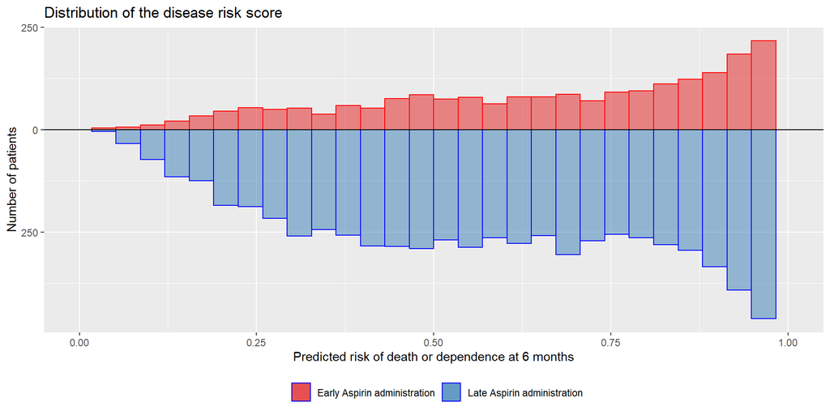

# Results

| Method | Estimate | SE | X95.CI | Time |
| --- | --- | --- | --- | --- |
| naive | 0.06 | 0.01 | 0.04 ; 0.08 | 0.02 |
| DSR NNM | -0.01 | 0.01 | -0.04 ; 0.01 | 1.19 |
| DSR OFM | 0.00 | 0.01 | -0.02 ; 0.02 | 83.33 |
| DSR IPW | -0.01 | 0.01 | -0.03 ; 0.01 | 0.10 |
| DSR TDW | 0.00 | 0.01 | -0.02 ; 0.02 | 0.11 |

Finally, we apply bootstrapping to improve estimation of standard errors:

| Method | Reference | Estimate | SE | X95.CI | Time |
| --- | --- | --- | --- | --- | --- |
| naive | 0 | 0.06 | 0.01 | 0.04 ; 0.08 | 5.66 |
| DSR NNM | 0 | -0.01 | 0.01 | -0.04 ; 0.01 | 582.07 |
| DSR OFM | 0 | -0.01 | 0.01 | -0.03 ; 0.01 | 72498.42 |
| DSR IPW | 0 | -0.01 | 0.01 | -0.02 ; 0.01 | 87.32 |
| DSR TDW | 0 | 0.00 | 0.01 | -0.02 ; 0.02 | 82.93 |